# Math 189 Homework 5: Data Analysis of Auto Mileage

Yunchun Pan, Siqing Lyu, Nathan Ng, Pudan Xu

2/16/2021

## Introduction

In this homework, we examine the auto dataset from the ISLR package[^1]. We will closely develop a model to predict whether a given car gets high or low gas mileage based on the Auto data set. The dataset has 392 observations on automobiles. For each automobile, we record the miles per gallon (MPG), among other variables such as horsepower and weight.

- **mpg**: miles per gallon

## Tasks

Analyze the dataset according to the following steps:

1. Create a binary variable, mgp01, that contains 1 if mpg contains a value above its median, and a 0 if mpg contains a value below its median. You can compute the median using the median() function.
2. Explore the data graphically in order to investigate the association between mgp01 and the other features. Which of the other features seem most likely to be useful in predicting mgp01? Scatterplots and boxplots may be useful tools to answer this question. Describe your findings.
3. Split the data into a training set of size 300 and a test set of size 92.
4. Perform LDA on the training data in order to predict mgp01 using the variables that seemed most associated with mgp01.
5. Classify the test data. Discuss the results in terms of the proportion of correctly classified records.

## Our Work

```r
library(ISLR)
data(Auto)
auto <- Auto
head(Auto)
```

|  | mpg | cylinders | displacement | horsepower | weight | acceleration | year | origin | name |
| --- | --- | --- | --- | --- | --- | --- | --- | --- | --- |
| 1 | 18 | 8 | 307 | 130 | 3504 | 12.0 | 70 | 1 | chevrolet chevelle malibu |
| 2 | 15 | 8 | 350 | 165 | 3693 | 11.5 | 70 | 1 | buick skylark 320 |
| 3 | 18 | 8 | 318 | 150 | 3436 | 11.0 | 70 | 1 | plymouth satellite |
| 4 | 16 | 8 | 304 | 150 | 3433 | 12.0 | 70 | 1 | amc rebel sst |
| 5 | 17 | 8 | 302 | 140 | 3449 | 10.5 | 70 | 1 | ford torino |
| 6 | 15 | 8 | 429 | 198 | 4341 | 10.0 | 70 | 1 | ford galaxie 500 |

```r
NA
```

1. Create a binary variable, mgp01, that contains 1 if mpg contains a value above its median, and a 0 if mpg contains a value below its median. You can compute the median using the median() function.

```r
mpg01 = c(dim(Auto)[1])
median_mpg = median(as.vector(Auto$mpg))
median_mpg
```

```
[1] 22.75
```

```r
mpg01[which(Auto$mpg > median_mpg)] <- 1
mpg01[which(Auto$mpg < median_mpg)] <- 0
Auto$mpg01 <- mpg01
head(Auto)
```

|  | mpg | cylinders | displacement | horsepower | weight | acceleration | year | origin | name | mpg01 |
| --- | --- | --- | --- | --- | --- | --- | --- | --- | --- | --- |
| 1 | 18 | 8 | 307 | 130 | 3504 | 12.0 | 70 | 1 | chevrolet chevelle malibu | 0 |
| 2 | 15 | 8 | 350 | 165 | 3693 | 11.5 | 70 | 1 | buick skylark 320 | 0 |
| 3 | 18 | 8 | 318 | 150 | 3436 | 11.0 | 70 | 1 | plymouth satellite | 0 |
| 4 | 16 | 8 | 304 | 150 | 3433 | 12.0 | 70 | 1 | amc rebel sst | 0 |
| 5 | 17 | 8 | 302 | 140 | 3449 | 10.5 | 70 | 1 | ford torino | 0 |
| 6 | 15 | 8 | 429 | 198 | 4341 | 10.0 | 70 | 1 | ford galaxie 500 | 0 |

2. Explore the data graphically in order to investigate the association between mgp01 and the other features. Which of the other features seem most likely to be useful in predicting mgp01? Scatterplots and boxplots may be useful tools to answer this question. Describe your findings.**displacement, horsepowr, and weight?**

```r
colnames(Auto)
```

```
 [1] "mpg"          "cylinders"    "displacement" "horsepower"   "weight"       "acceleration" "year"
 [8] "origin"       "name"         "mpg01"
```

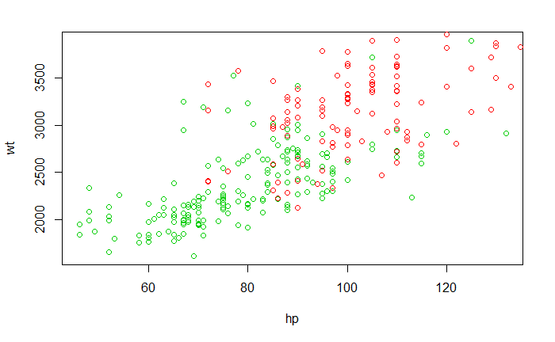

```r
plot(x = mpg_good$horsepower, y = mpg_good$weight,col=3,
     xlab = "hp",ylab = "wt")
points(x = mpg_bad$horsepower, y = mpg_bad$weight,col=2)
```

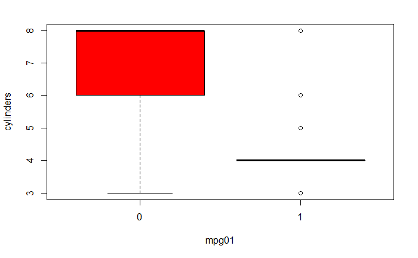

```r
boxplot(cylinders ~ mpg01, data=Auto, col=c(2,3))
```

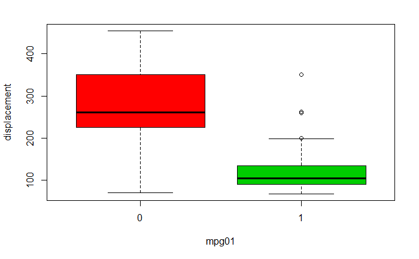

```r
boxplot(displacement ~ mpg01, data=Auto, col=c(2,3))
```

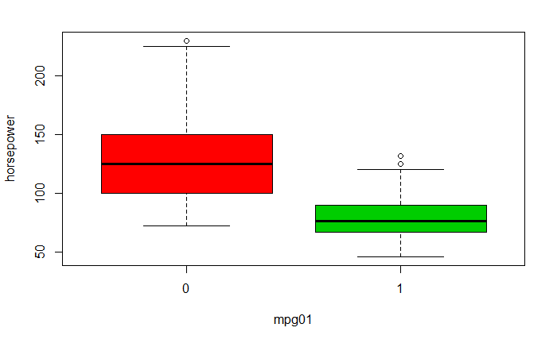

```r
boxplot(horsepower ~ mpg01, data=Auto, col=c(2,3))
```

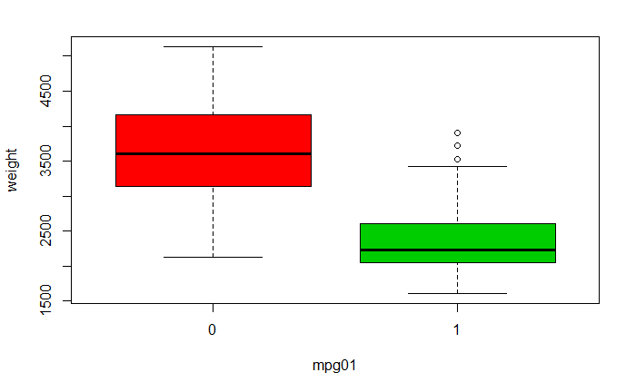

```r
boxplot(weight ~ mpg01, data=Auto, col=c(2,3))
```

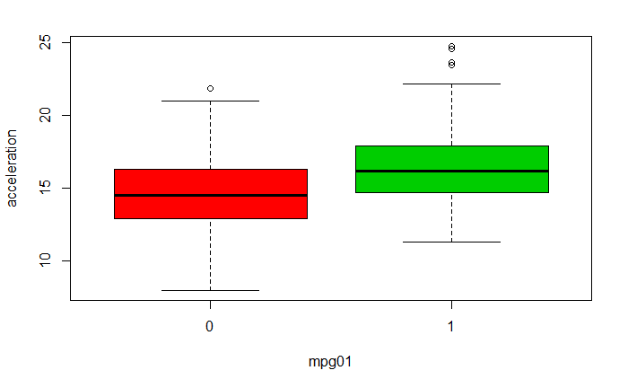

```r
boxplot(acceleration ~ mpg01, data=Auto, col=c(2,3))
```

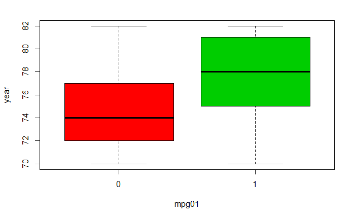

```r
boxplot(year ~ mpg01, data=Auto, col=c(2,3))
```

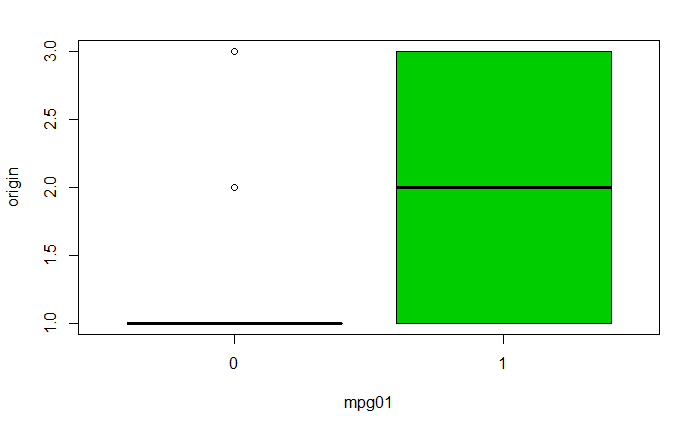

```r
boxplot(origin ~ mpg01, data=Auto, col=c(2,3))
```

3. Split the data into a training set of size 300 and a test set of size 92.

```r
mpg.good <- Auto[Auto$mpg01 == 1,]
mpg.bad <- Auto[Auto$mpg01 == 0,]
dim(mpg.good)[1]
```

```
[1] 196
```

```r
dim(mpg.bad)[1]
```

```
[1] 196
```

```r
auto.train <- rbind(mpg.good[1:150,],mpg.bad[1:150,])
auto.test <- rbind(mpg.good[151:dim(mpg.good)[1],],mpg.bad[151:dim(mpg.bad)[1],])
n_good <- 150
n_bad <- 150

#Prior: relative sample size in train data
p_good <- n_good/300
p_bad <- n_bad/300
```

4. Perform LDA on the training data in order to predict mgp01 using the variables that seemed most associated with mgp01.

### Auto Sample Mean Vectors

```r
Mean_good <- colMeans(auto.train[auto.train$mpg01 == 1,c("displacement","horsepower","weight", "acceleration")])
Mean_bad <- colMeans(auto.train[auto.train$mpg01 == 0,c("displacement","horsepower","weight","acceleration")])

rbind(Mean_good,Mean_bad)
```

```
          displacement horsepower   weight acceleration
Mean_good     112.5767   78.45333 2298.427     16.44400
Mean_bad      281.3067  133.16667 3679.427     14.42067
```

### Auto Pooled Sample Covariance

```r
S_good <- cov(auto.train[auto.train$mpg01 == 1,c("displacement","horsepower","weight","acceleration")])
S_bad <- cov(auto.train[auto.train$mpg01 == 0,c("displacement","horsepower","weight","acceleration")])

S_pooled <- ((n_good-1)*S_good +(n_bad-1)*S_bad)/(n_good+n_bad-2)
S_pooled
```

```
             displacement  horsepower      weight acceleration
displacement    4779.4002  1727.84268  33406.9009   -92.937103
horsepower      1727.8427   915.44298  12862.1118   -54.398687
weight         33406.9009 12862.11181 332214.7698  -429.823284
acceleration     -92.9371   -54.39869   -429.8233     7.180925
```

### Intercepts of Linear Discriminant Function

```r
S_inv <- solve(S_pooled)
alpha_good <- -0.5* t(Mean_good) %*% S_inv %*% Mean_good + log(p_good)
alpha_bad <- -0.5* t(Mean_bad) %*% S_inv %*% Mean_bad + log(p_bad)

alpha_auto <- c(alpha_good,alpha_bad)
alpha_auto
```

```
[1] -63.10237 -73.77578
```

### Slope Coefficients of Linear Discriminant Function

```r
beta_good <- S_inv %*% Mean_good
beta_bad <- S_inv %*% Mean_bad

beta_auto <- cbind(beta_good,beta_bad)
beta_auto
```

```
                     [,1]          [,2]
displacement -0.050998112 -0.0208513980
horsepower    0.533150217  0.5101242604
weight       -0.001366289  0.0007273458
acceleration  5.586995284  5.6462810003
```

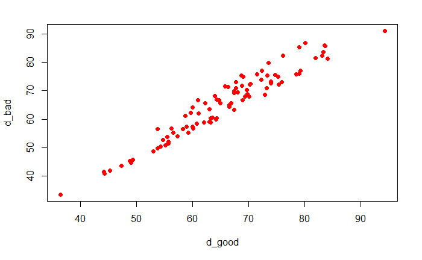

```r
prediction <- c()
d_good_vec <- c()
d_bad_vec <- c()
d_virginica_vec <- c()
label <- c(1, 0)

for(i in 1:nrow(auto.test)){
    #Read an ovservation in test data
    x <- t(auto.test[i,c("displacement","horsepower","weight", "acceleration")])

    #Calculate linear discriminant functions for each
    d_good <- alpha_good + t(beta_good) %*% x
    d_bad <- alpha_bad + t(beta_bad) %*% x

    #Classify the observation to the class with highest function value
    d_vec <- c(d_good, d_bad)
    prediction <- append(prediction, label[which.max( d_vec )])

    d_good_vec <- append(d_good_vec, d_good)
    d_bad_vec <- append(d_bad_vec, d_bad)
}

#Combine the predicted results to the test dataset.
auto.test$prediction <- prediction

#3D scatter plot
library("scatterplot3d")
col_vec <- c(rep("red", 92), rep("blue", 92))
pch_vec <- c(rep(15, 92), rep(17, 92))

plot(x = d_good_vec, y = d_bad_vec, xlab = "d_good", ylab = "d_bad",
              col="red", pch=19)
```

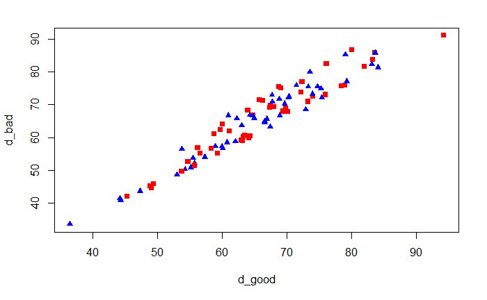

```r
plot(x = d_good_vec, y = d_bad_vec,
              xlab = "d_good", ylab = "d_bad",
              col=c(2,4), pch=c(15,17))
```

- The classification results versus truth are given in the following output:

```r
good_true <- sum((auto.test$mpg01 == 1) & (auto.test$prediction == 1))
bad_true <- sum((auto.test$mpg01 == 0) & (auto.test$prediction == 0))

auto.test
```

|  | mpg | cylinders | displacement | horsepower | weight | acceleration | year | origin | name | mpg01 | prediction |
| --- | --- | --- | --- | --- | --- | --- | --- | --- | --- | --- | --- |
| 347 | 32.3 | 4 | 97 | 67 | 2065 | 17.8 | 81 | 3 | subaru | 1 | 1 |
| 348 | 37.0 | 4 | 85 | 65 | 1975 | 19.4 | 81 | 3 | datsun 210 mpg | 1 | 1 |
| 349 | 37.7 | 4 | 89 | 62 | 2050 | 17.3 | 81 | 3 | toyota tercel | 1 | 1 |
| 350 | 34.1 | 4 | 91 | 68 | 1985 | 16.0 | 81 | 3 | mazda glc 4 | 1 | 1 |
| 351 | 34.7 | 4 | 105 | 63 | 2215 | 14.9 | 81 | 1 | plymouth horizon 4 | 1 | 1 |
| 352 | 34.4 | 4 | 98 | 65 | 2045 | 16.2 | 81 | 1 | ford escort 4w | 1 | 1 |
| 353 | 29.9 | 4 | 98 | 65 | 2380 | 20.7 | 81 | 1 | ford escort 2h | 1 | 1 |
| 354 | 33.0 | 4 | 105 | 74 | 2190 | 14.2 | 81 | 2 | volkswagen jetta | 1 | 1 |
| 356 | 33.7 | 4 | 107 | 75 | 2210 | 14.4 | 81 | 3 | honda prelude | 1 | 1 |
| 357 | 32.4 | 4 | 108 | 75 | 2350 | 16.8 | 81 | 3 | toyota corolla | 1 | 1 |

[output cut: 82 more lines]

- The table summarizes the results.

```r
class_tab <- c(dim(mpg.good)[1]-n_good,
               dim(mpg.bad)[1]-n_bad)
class_tab <- rbind(class_tab,
       c(good_true,bad_true))
class_tab <- rbind(class_tab,class_tab[1,] - class_tab[2,])
colnames(class_tab) <- c("good","bad")
rownames(class_tab) <- c("Number Observations","Number Correct","Number Wrong")
class_tab
```

```
                    good bad
Number Observations   46  46
Number Correct        44  37
Number Wrong           2   9
```